# An Introduction to Statistical Learning (2013)

Chapter Code

by Brian Hassett

# Chapter 6 Linear Model Selection and Regularization

This notebook is a rough outline of **Chapter 6** of **An Introduction to Statistical Learning** (James et al. (2013)[^1]).

The authors do not provide code for the analysis or figures used throughout each chapter. They do however provide access to some of the data. This notebook uses the data to recreate *some* of the analysis and figures from the chapter.

## Setup

```r
library(ISLR)
library(tidyverse)
library(leaps)
library(glmnet)
library(patchwork)
theme_set(theme_bw())

# Given a file name, return the file path. Default folder is the `data` folder in the current working directory.
get_path <- function(filename) {
  str_c(getwd(), "data", filename, sep = "/")
}

# Data:
Credit <- dplyr::select(Credit, -ID) # remove the ID variable from the Credit data

# Colors:
ISLR_blue <- "#176FC0"
ISLR_brown <- "#94340E"
ISLR_lightblue <- "#68A5DB"
ISLR_orange <- "#CC5318"
```

## 6.1 Subset Selection

View `Credit` data:

```r
Credit
```

| Income | Limit | Rating | Cards | Age | Education | Gender | Student | Married | Ethnicity | Balance |
| --- | --- | --- | --- | --- | --- | --- | --- | --- | --- | --- |
| 14.891 | 3606 | 283 | 2 | 34 | 11 | Male | No | Yes | Caucasian | 333 |
| 106.025 | 6645 | 483 | 3 | 82 | 15 | Female | Yes | Yes | Asian | 903 |
| 104.593 | 7075 | 514 | 4 | 71 | 11 | Male | No | No | Asian | 580 |
| 148.924 | 9504 | 681 | 3 | 36 | 11 | Female | No | No | Asian | 964 |
| 55.882 | 4897 | 357 | 2 | 68 | 16 | Male | No | Yes | Caucasian | 331 |
| 80.180 | 8047 | 569 | 4 | 77 | 10 | Male | No | No | Caucasian | 1151 |
| 20.996 | 3388 | 259 | 2 | 37 | 12 | Female | No | No | African American | 203 |
| 71.408 | 7114 | 512 | 2 | 87 | 9 | Male | No | No | Asian | 872 |
| 15.125 | 3300 | 266 | 5 | 66 | 13 | Female | No | No | Caucasian | 279 |
| 71.061 | 6819 | 491 | 3 | 41 | 19 | Female | Yes | Yes | African American | 1350 |

[output cut: 390 more lines]

### FIGURE 6.1

This figure shows the RSS and $R^2$ for *every possible model* generated from the `Credit` data. I have used the `regsubsets` function from the `leaps` package for this. The default value of `nbest` is `1` meaning that the RSS and $R^2$ is only recorded for the best model. This has been set to `462` to capture all possible models. This is equivalent to ${11 \choose 6}$ and ${11 \choose 5}$. Despite the large number of models the computational time is *not* an issue with this data:

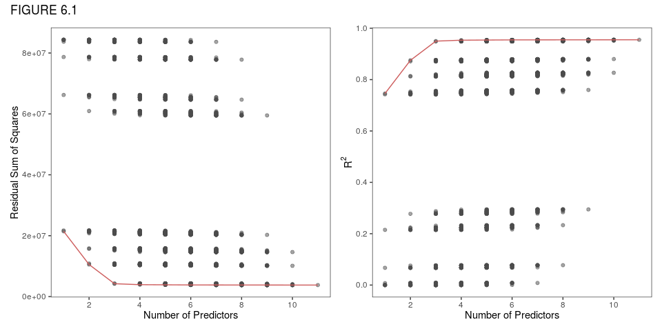

```r
# Perform best subset selection:
mod1 <- regsubsets(Balance ~ ., Credit,
                   nvmax = 11, # 10 predictors but one is categorical with 3 levels so use 11 here
                   nbest = 462, # (11 C 5) = (11 C 6) = 462
                   really.big = T)

# The summary contains the RSS and R Squared values:
mod1_sum <- summary(mod1)

# Get a vector of the number of variables in each model:
num_vars <- rowSums(data.frame(mod1_sum$which)) - 1

# Data frame of number of predictors and the RSS and R Squared of each model:
all_mods <- data.frame(num_var = num_vars, rss = mod1_sum$rss, rsq = mod1_sum$rsq)

# Plot RSS:
p1 <- all_mods %>%
  ggplot(aes(num_var, rss)) +
  geom_point(color = "grey30", alpha = 0.5) +
  geom_line(data = summarize(group_by(all_mods, num_var), min = min(rss)),
            aes(num_var, min),
            color = "indianred") +
  scale_x_continuous(breaks = seq(2, 10, 2)) +
  labs(x = "Number of Predictors", y = "Residual Sum of Squares") +
  theme(panel.grid = element_blank())

# Plot R Squared
p2 <- all_mods %>%
  ggplot(aes(num_var, rsq)) +
  geom_point(color = "grey30", alpha = 0.5) +
  geom_line(data = summarize(group_by(all_mods, num_var), max = max(rsq)),
            aes(num_var, max),
            color = "indianred") +
  scale_x_continuous(breaks = seq(2, 10, 2)) +
  scale_y_continuous(breaks = seq(0, 1, 0.2)) +
  labs(x = "Number of Predictors", y = expression(R^2)) +
  theme(panel.grid = element_blank())

p1 + p2 + plot_annotation(title = "FIGURE 6.1")
```

### TABLE 6.1

*The first four selected models for best subset selection and forward stepwise selection on the `Credit` data set. The first three models are identical but the fourth models differ.*

```r
# Best subset:
mod_best <- regsubsets(Balance ~ ., Credit, nvmax = 4, nbest = 1, method = "exhaustive")
mod_best_summary <- summary(mod_best)

# Forward stepwise:
mod_forward <- regsubsets(Balance ~ ., Credit, nvmax = 4, nbest = 1, method = "forward")
mod_forward_summary <- summary(mod_forward)

# Variables used in each model:
mod_best_vars <- apply(mod_best_summary$which[ , -1], 1, function(x) names(which(x)))
mod_forward_vars <- apply(mod_forward_summary$which[ , -1], 1, function(x) names(which(x)))

data.frame(`Number of Variables` = c("One", "Two", "Three", "Four"),
           `Best subset` = map_chr(mod_best_vars, ~paste0(.x, collapse = ", ")),
           `Forward stepwise` = map_chr(mod_forward_vars, ~paste0(.x, collapse = ", ")))
```

|  | Number.of.Variables | Best.subset | Forward.stepwise |
| --- | --- | --- | --- |
| 1 | One | Rating | Rating |
| 2 | Two | Income, Rating | Income, Rating |
| 3 | Three | Income, Rating, StudentYes | Income, Rating, StudentYes |
| 4 | Four | Income, Limit, Cards, StudentYes | Income, Limit, Rating, StudentYes |

### FIGURE 6.2

The BIC and $C_p$ values as calculated by `regsubsets` are different to the values in the book. The shape of the plots is the same, and the minimum values occur for the same number of variables. These criteria can be reported as changes or ratios, but the important thing finding the model with the minimum value rather than looking at the actual values. In the lab of this chapter, they actually use the same output as I have in these plots (negative values for BIC). If I figure out how the authors scaled the y-axis for the first two plots in this figure I will change it. The adjusted $R^2$ values and plot are the same as the book.

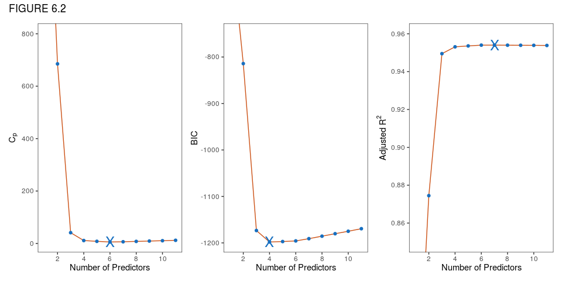

```r
mod2 <- regsubsets(Balance ~ ., Credit, nvmax = 11, nbest = 1, method = "exhaustive")
mod2_sum <- summary(mod2)

mod2_df <-
  data.frame(
    num_vars = 1:11,
    cp = mod2_sum$cp,
    bic = mod2_sum$bic,
    adrsq = mod2_sum$adjr2)

p1 <- ggplot(mod2_df, aes(num_vars, cp)) +
  geom_line(color = ISLR_orange) +
  geom_point(color = ISLR_blue) +
  geom_point(data = dplyr::filter(mod2_df, cp == min(mod2_df$cp)),
             aes(num_vars, cp), shape = "X", color = ISLR_blue, size = 6) +
  scale_x_continuous(breaks = seq(2, 10, 2)) +
  coord_cartesian(ylim = c(NA, 800)) + # the plots in the book are on a different scale so this is a approximate
  labs(x = "Number of Predictors", y = expression(C[p])) +
  theme(panel.grid = element_blank())

p2 <- ggplot(mod2_df, aes(num_vars, bic)) +
  geom_line(color = ISLR_orange) +
  geom_point(color = ISLR_blue) +
  geom_point(data = dplyr::filter(mod2_df, bic == min(mod2_df$bic)),
             aes(num_vars, bic), shape = "X", color = ISLR_blue, size = 6) +
  scale_x_continuous(breaks = seq(2, 10, 2)) +
  coord_cartesian(ylim = c(NA, -750)) + # the plots in the book are on a different scale so this is a approximate
  labs(x = "Number of Predictors", y = "BIC") +
  theme(panel.grid = element_blank())

p3 <- ggplot(mod2_df, aes(num_vars, adrsq)) +
  geom_line(color = ISLR_orange) +
  geom_point(color = ISLR_blue) +
  geom_point(data = dplyr::filter(mod2_df, adrsq == max(mod2_df$adrsq)),
             aes(num_vars, adrsq), shape = "X", color = ISLR_blue, size = 6) +
  scale_x_continuous(breaks = seq(2, 10, 2)) +
  scale_y_continuous(breaks = seq(0.86, 0.96, 0.02)) +
  coord_cartesian(ylim = c(0.85, 0.96)) +
  labs(x = "Number of Predictors", y = expression(paste("Adjusted ", R^2))) +
  theme(panel.grid = element_blank())

p1 + p2 + p3 + plot_annotation(title = "FIGURE 6.2")
```

### FIGURE 6.3

These plots have the same issue as FIGURE 6.2 in that the scales are different. The shapes are the same though, allowing for some differences due to the splits chosen for the validation and cross-validation sets. The code for this plot is adapted from some of the code used in the lab for this chapter.

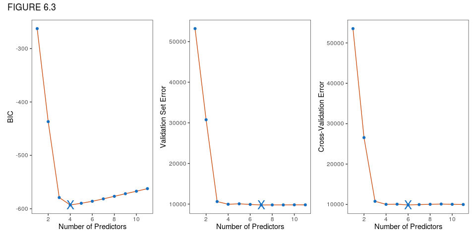

```r
set.seed(1)

# Split the data into a training and test (validation) set:
train <- sample(c(TRUE, FALSE), nrow(Credit), rep = TRUE)
test <- (!train)

# Fit a model using best subset selection and evaluate on the test data:
p <- 11
mod3 <- regsubsets(Balance ~ ., Credit[train, ], nvmax = p)
test.mat <- model.matrix(Balance ~ ., data = Credit[test, ])
val_errors <- rep(NA, p)
for(i in 1:p) {
  coefi <- coef(mod3, id = i)
  pred <- test.mat[ , names(coefi)] %*% coefi
  val_errors[i] <- mean((Credit$Balance[test] - pred)^2)
}

# Function for making predictions with CV:
predict.regsubsets <- function(object, newdata, id,...) {
  form <- as.formula(object$call[[2]])
  mat <- model.matrix(form, newdata)
  coefi <- coef(object, id=id)
  xvars <- names(coefi)
  mat[, xvars]%*%coefi
}

# Fit a model using best subset selection and evaluate using 10-fold CV:
k = 10
set.seed(1)
folds <- sample(1:k, nrow(Credit), replace=TRUE)
cv_errors <- matrix(NA, k, p, dimnames=list(NULL, paste(1:p)))
for(j in 1:k) {
  best.fit <- regsubsets(Balance ~ ., data=Credit[folds!=j, ], nvmax=p)
  for(i in 1:p) {
    pred <- predict.regsubsets(best.fit, Credit[folds==j, ], id=i)
    cv_errors[j, i] = mean((Credit$Balance[folds==j] - pred)^2)
  }
}

# Collect the errors:
df_6.4 <-
  data.frame(
    num_vars = 1:p,
    bic = summary(mod3)$bic,
    val_error = val_errors,
    cv_error = apply(cv_errors, 2, mean))

# Plot:
p1 <- ggplot(df_6.4, aes(num_vars, bic)) +
  geom_line(color = ISLR_orange) +
  geom_point(color = ISLR_blue) +
  geom_point(data = dplyr::filter(df_6.4, bic == min(df_6.4$bic)),
             aes(num_vars, bic), shape = "X", color = ISLR_blue, size = 6) +
  scale_x_continuous(breaks = seq(2, 10, 2)) +
  labs(x = "Number of Predictors", y = "BIC") +
  theme(panel.grid = element_blank())

p2 <- ggplot(df_6.4, aes(num_vars, val_error)) +
  geom_line(color = ISLR_orange) +
  geom_point(color = ISLR_blue) +
  geom_point(data = dplyr::filter(df_6.4, val_error == min(df_6.4$val_error)),
             aes(num_vars, val_error), shape = "X", color = ISLR_blue, size = 6) +
  scale_x_continuous(breaks = seq(2, 10, 2)) +
  labs(x = "Number of Predictors", y = "Validation Set Error") +
  theme(panel.grid = element_blank())

p3 <- ggplot(df_6.4, aes(num_vars, cv_error)) +
  geom_line(color = ISLR_orange) +
  geom_point(color = ISLR_blue) +
  geom_point(data = dplyr::filter(df_6.4, cv_error == min(df_6.4$cv_error)),
             aes(num_vars, cv_error), shape = "X", color = ISLR_blue, size = 6) +
  scale_x_continuous(breaks = seq(2, 10, 2)) +
  labs(x = "Number of Predictors", y = "Cross-Validation Error") +
  theme(panel.grid = element_blank())

p1 + p2 + p3 + plot_annotation(title = "FIGURE 6.3")
```

## 6.2 Shrinkage Methods

### FIGURE 6.4

The left panel is a plot of the ridge regression coefficients against $\lambda$, with the curves for four of the variables highlighted. The right panel requires calculation of the $l_2$ norm for the ridge regression coefficients. The ratio of the $l_2$ norm of the ridge regression coefficients and least squares coefficients is plotted on the x-axis, the ridge regression coefficients are plotted on the y-axis:

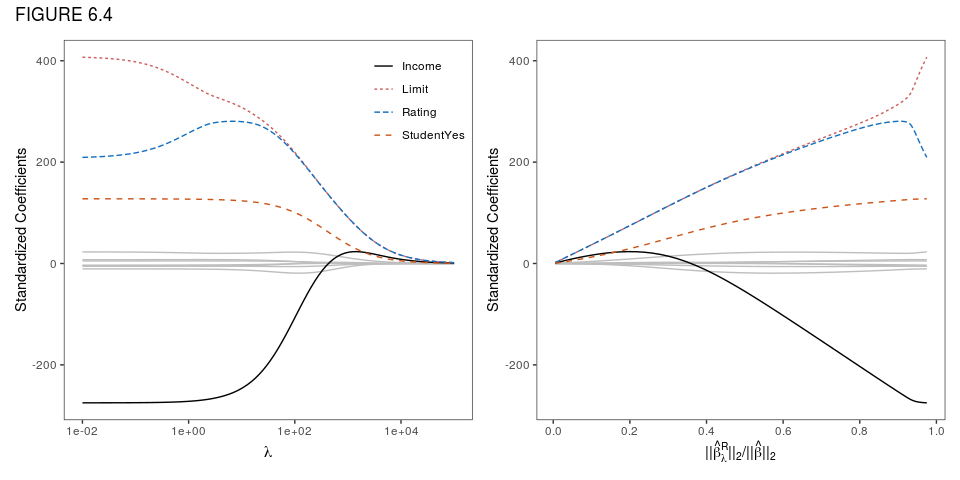

```r
# Left panel #

# Grid of lambda values:
grid <- 10^seq(5, -2, length = 100)

# Use a model matrix for glmnet():
X <- model.matrix(Balance ~ ., Credit)[, -1]
y <- Credit$Balance

# Fit a ridge regression model.
# Scale the X values:
ridge_mod1 <- glmnet(scale(X, center = TRUE), y, alpha = 0, lambda = grid) # use scale() to match the text
ridge_mod_summary <- summary(ridge_mod1)

# Data frame of the ridge coefficients and lambda values:
ridge_mod1_coef <- coef(ridge_mod1) %>%
  as.matrix() %>%
  data.frame() %>%
  tibble::rownames_to_column("var") %>%
  pivot_longer(starts_with("s"), names_to = "s", values_to = "coef") %>%
  mutate(lambda = rep(grid, 12)) %>%
  dplyr::select(var, lambda, coef) %>%
  filter(var != "(Intercept)")

# Plot:
p1 <- ggplot() +
  geom_line(data = dplyr::filter(ridge_mod1_coef, !(var %in% c("Income", "Limit", "Rating", "StudentYes"))),
            aes(lambda, coef, group = var),
            color = "grey") +
  geom_line(data = dplyr::filter(ridge_mod1_coef, (var %in% c("Income", "Limit", "Rating", "StudentYes"))),
            aes(lambda, coef, color = var, linetype = var)) +
  scale_x_log10(breaks = 10^seq(-2, 4, 2)) +
  scale_color_manual(values = c("black", "indianred", ISLR_blue, ISLR_orange)) +
  labs(x = expression(lambda), y = "Standardized Coefficients", color = NULL, linetype = NULL) +
  theme(panel.grid = element_blank(),
        legend.position = c(1, 1),
        legend.justification = c(1, 1),
        legend.background = element_blank())

# Right panel #

# Function to calculate l2 norm:
l2_norm <- function(x) sqrt(sum(x^2))

# Least squares coefficients:
# (use the same model matrix as with the ridge model, and scale the X values)
least_square_coef <- coef(lm(y ~ scale(X, center = TRUE)))[-1] # remove intercept

# Calculate the l2 norm of the ridge coefficients:
ridge_coef_norms <- coef(ridge_mod1)[-1, ] %>% # remove the intercept
  as.matrix() %>%
  apply(2, l2_norm)

# Divide to get the ratio:
l2_ratio <- ridge_coef_norms/l2_norm(least_square_coef)

# Add the ratio to the data frame of ridge coefficients and plot:
ridge_mod1_coef <- ridge_mod1_coef %>%
  mutate(l2_ratio = rep(l2_ratio, 11))

p2 <- ggplot() +
  geom_line(data = dplyr::filter(ridge_mod1_coef, !(var %in% c("Income", "Limit", "Rating", "StudentYes"))),
            aes(l2_ratio, coef, group = var),
            color = "grey") +
  geom_line(data = dplyr::filter(ridge_mod1_coef, (var %in% c("Income", "Limit", "Rating", "StudentYes"))),
            aes(l2_ratio, coef, color = var, linetype = var)) +
  scale_color_manual(values = c("black", "indianred", ISLR_blue, ISLR_orange)) +
  scale_x_continuous(breaks = seq(0, 1, 0.2)) +
  labs(x = latex2exp::TeX("$||\\hat{\\beta}^R_{\\lambda} ||_2/||\\hat{\\beta}||_2$"), y = "Standardized Coefficients", color = NULL, linetype = NULL) +
  theme(panel.grid = element_blank(),
        legend.position = "none")

p1 + p2 + plot_annotation(title = "FIGURE 6.4")
```

### FIGURE 6.5

This is based on a simulated data set which I do not have.

### FIGURE 6.6

The left panel is a plot of the lasso coefficients against $\lambda$, with the curves for four of the variables highlighted. The right panel requires calculation of the $l_1$ norm for the lasso coefficients. The ratio of the $l_1$ norm of the lasso coefficients and least squares coefficients is plotted on the x-axis, the lasso coefficients are plotted on the y-axis. Unlike with the ridge regression plots these are not exactly like the text. The shape of the curves is the same but the $\lambda$ values are diffrent. I opted to use the `nlambda` argument here as it was easier to get the correct shape than a manual grid. There may be an issue with scaling that I have missed that makes the plots different to the text.

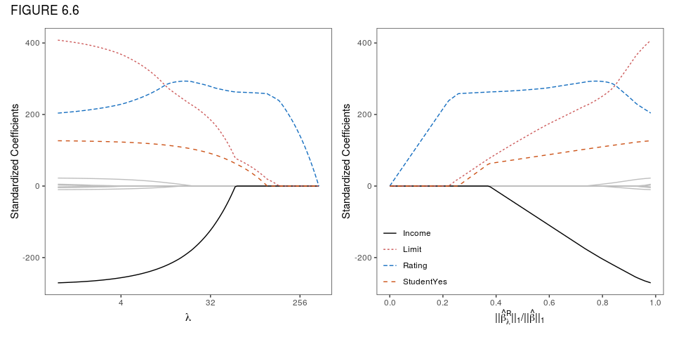

```r
# Left panel #

# Use a model matrix for glmnet():
X <- model.matrix(Balance ~ ., Credit)[, -1]
y <- Credit$Balance

# Fit a lasso model.
# (scale the X values, use nlambda instead of a grid)
lasso_mod1 <- glmnet(scale(X, center = TRUE), y, alpha = 1, nlambda = 200) # use scale() to match the text
lasso_mod_summary <- summary(lasso_mod1)

# Data frame of the lasso coefficients and lambda values:
lasso_mod1_coef <- coef(lasso_mod1) %>%
  as.matrix() %>%
  data.frame() %>%
  tibble::rownames_to_column("var") %>%
  pivot_longer(starts_with("s"), names_to = "s", values_to = "coef") %>%
  mutate(lambda = rep(lasso_mod1$lambda, 12)) %>%
  dplyr::select(var, lambda, coef) %>%
  filter(var != "(Intercept)")

# Plot:
p1 <- ggplot() +
  geom_line(data = dplyr::filter(lasso_mod1_coef, !(var %in% c("Income", "Limit", "Rating", "StudentYes"))),
            aes(lambda, coef, group = var),
            color = "grey") +
  geom_line(data = dplyr::filter(lasso_mod1_coef, (var %in% c("Income", "Limit", "Rating", "StudentYes"))),
            aes(lambda, coef, color = var, linetype = var)) +
  scale_x_continuous(trans = "log2") +
  scale_color_manual(values = c("black", "indianred", ISLR_blue, ISLR_orange)) +
  labs(x = expression(lambda), y = "Standardized Coefficients", color = NULL, linetype = NULL) +
  theme(panel.grid = element_blank(),
        legend.position = "none")

# Right panel #

# Function to calculate l2 norm:
l1_norm <- function(x) sum(abs(x))

# Least squares coefficients:
# (use the same model matrix as with the ridge model, and scale the X values)
least_square_coef <- coef(lm(y ~ scale(X, center = TRUE)))[-1] # remove intercept

# Calculate the l2 norm of the ridge coefficients:
lasso_coef_norms <- coef(lasso_mod1)[-1, ] %>% # remove the intercept
  as.matrix() %>%
  apply(2, l1_norm)

# Divide to get the ratio:
l1_ratio <- lasso_coef_norms/l1_norm(least_square_coef)

# Add the ratio to the data frame of ridge coefficients and plot:
lasso_mod1_coef <- lasso_mod1_coef %>%
  mutate(l1_ratio = rep(l1_ratio, 11))

p2 <- ggplot() +
  geom_line(data = dplyr::filter(lasso_mod1_coef, !(var %in% c("Income", "Limit", "Rating", "StudentYes"))),
            aes(l1_ratio, coef, group = var),
            color = "grey") +
  geom_line(data = dplyr::filter(lasso_mod1_coef, (var %in% c("Income", "Limit", "Rating", "StudentYes"))),
            aes(l1_ratio, coef, color = var, linetype = var)) +
  scale_color_manual(values = c("black", "indianred", ISLR_blue, ISLR_orange)) +
  scale_x_continuous(breaks = seq(0, 1, 0.2)) +
  labs(x = latex2exp::TeX("$||\\hat{\\beta}^R_{\\lambda} ||_1/||\\hat{\\beta}||_1$"), y = "Standardized Coefficients", color = NULL, linetype = NULL) +
  theme(panel.grid = element_blank(),
        legend.position = c(0, 0),
        legend.justification = c(0, 0),
        legend.background = element_blank())

p1 + p2 + plot_annotation(title = "FIGURE 6.6")
```

### FIGURE 6.8

This is based on a simulated data set which I do not have.

### FIGURE 6.9

This is based on a simulated data set which I do not have.

### FIGURE 6.10

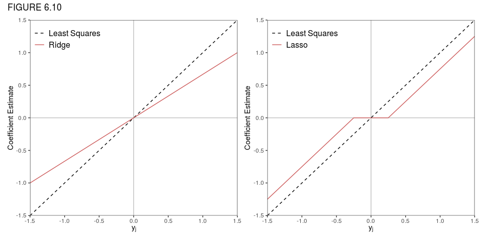

```r
n <- 5
p <- 5
X <- matrix(0, nrow = n, ncol = p)
diag(X) <- 1
yj <- seq(-1.5, 1.5, by = 0.01) # chose this range based on the plot, keep the step size small to make the plot look nice
lambda <- 0.5 # I just chose this, but it works well
df_6.10 <-
  data.frame(
    y = yj,
    least_squares = yj, # (6.11)
    ridge = yj/(1 + lambda), # (6.14)
    lasso = if_else(yj > lambda/2, yj - lambda/2, if_else(yj < -lambda/2, yj + lambda/2, 0)) # (6.15)
  ) %>%
    pivot_longer(cols = !starts_with("y"), names_to = "type", values_to = "coef") %>%
    select(type, y, coef)

# Plot least squares and ridge lines:
p1 <- df_6.10 %>%
  filter(type != "lasso") %>%
  ggplot() +
  geom_hline(yintercept = 0, color = "grey") +
  geom_vline(xintercept = 0, color = "grey") +
  geom_line(aes(y, coef, color = type, linetype = type)) +
  scale_color_manual(breaks = c("least_squares", "ridge"),
                     labels = c("Least Squares", "Ridge"),
                     values = c("black", "indianred")) +
  scale_linetype_manual(breaks = c("least_squares", "ridge"),
                        labels = c("Least Squares", "Ridge"),
                        values = c("dashed", "solid")) +
  scale_x_continuous(breaks = seq(-1.5, 1.5, 0.5)) +
  labs(x = expression(y[j]), y = "Coefficient Estimate",
       color = NULL, linetype = NULL) +
  coord_cartesian(expand = F) +
  theme(legend.position = c(0, 1),
        legend.justification = c(0, 1),
        legend.background = element_blank(),
        legend.text = element_text(size = 12),
        panel.grid = element_blank())

# Plot least squares and lasso lines:
p2 <- df_6.10 %>%
  filter(type != "ridge") %>%
  ggplot() +
  geom_hline(yintercept = 0, color = "grey") +
  geom_vline(xintercept = 0, color = "grey") +
  geom_line(aes(y, coef, color = type, linetype = type)) +
  scale_color_manual(breaks = c("least_squares", "lasso"),
                     labels = c("Least Squares", "Lasso"),
                     values = c("black", "indianred")) +
  scale_linetype_manual(breaks = c("least_squares", "lasso"),
                        labels = c("Least Squares", "Lasso"),
                        values = c("dashed", "solid")) +
  scale_x_continuous(breaks = seq(-1.5, 1.5, 0.5)) +
  labs(x = expression(y[j]), y = "Coefficient Estimate",
       color = NULL, linetype = NULL) +
  coord_cartesian(expand = F) +
  theme(legend.position = c(0, 1),
        legend.justification = c(0, 1),
        legend.background = element_blank(),
        legend.text = element_text(size = 12),
        panel.grid = element_blank())

p1 + p2 + plot_annotation(title = "FIGURE 6.10")
```

[^1]: James G, Witten D, Hastie T, Tibshirani R (2013). *An Introduction to Statistical Learning: with Applications in R*. Springer, 1st edition.